# Analysis // #dontretirekid trends

Phil Walker

17 May, 2020

# Overview

The hashtag “#dontretirekid” was part of the [Aspen Institute’s media program](https://www.aspenprojectplay.org/dont-retire-kid) as part of the larger Project Play initiative to help promote youth sports.

We would like to be able to capture all of the tweets related to this hashtag to better understand the breadth of the expoure. Ideally, this data could then be used to assess how effective it was, or what areas it resonated with

Below is an example of the ads that helped to spread this message out to sport consumers.

[video not shown]

These ads are mean

# Gather Data

## Twitter

Starting with all tweets from the Aspen Institute timeline

```r
tl_AspendIn <-
  get_timeline("AspenInstSports", n = 5200) %>%
  select(status_id, reply_to_status_id, created_at, screen_name, reply_to_screen_name, mentions_screen_name,
         text, source, hashtags, urls_expanded_url, media_url,
         geo_coords, country, location,
         account_created_at, followers_count, friends_count)

tl_AspendIn %>%
  select(hashtags) %>%
  unnest(cols = c(hashtags)) %>%
  count(hashtags, sort = TRUE) %>%
  DT::datatable()
```

|  | hashtags | n |
| --- | --- | --- |
| 1 |  | 1779 |
| 2 | ProjectPlay | 575 |
| 3 | DontRetireKid | 351 |
| 4 | AspenSportsLab | 176 |
| 5 | HealthySportIndex | 90 |
| 6 | CallsForCoaches | 54 |
| 7 | ProjectPlayHarlem | 28 |
| 8 | ProjectPlayBmore | 20 |
| 9 | COVID19 | 14 |
| 10 | sportsampling | 12 |

[output cut: 140 more lines]

```r
dontRetire_AIS <-
  tl_AspendIn %>%
  filter(str_detect(text, regex("#dontretirekid", ignore_case = TRUE)))

FirstDontRetire <- min(dontRetire_AIS$created_at)
LastDontRetire <- max(dontRetire_AIS$created_at)
```

The campaign looks like it started at **2019-07-09 17:53:39** with the last tagged tweet from the Aspen Institute coming at **2020-03-11 17:31:57**

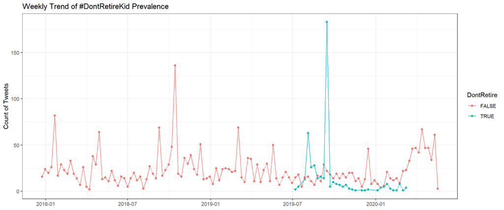

```r
tl_AspendIn %>%
  unnest(cols = c(hashtags)) %>%
  mutate(tweetDT = as.Date(created_at),
         DontRetire = str_detect(text, regex("#dontretirekid", ignore_case = TRUE)),
         tweetWK = lubridate::floor_date(tweetDT, "weeks")) %>%
  count(tweetWK, DontRetire) %>%
  ggplot(aes(tweetWK, n, color=DontRetire))+
    geom_point()+
    geom_line()+
    theme_bw()+
    labs(title = "Weekly Trend of #DontRetireKid Prevalence",
         x = NULL, y= "Count of Tweets")
```

Network graph of recent interactions with #dontretirekid

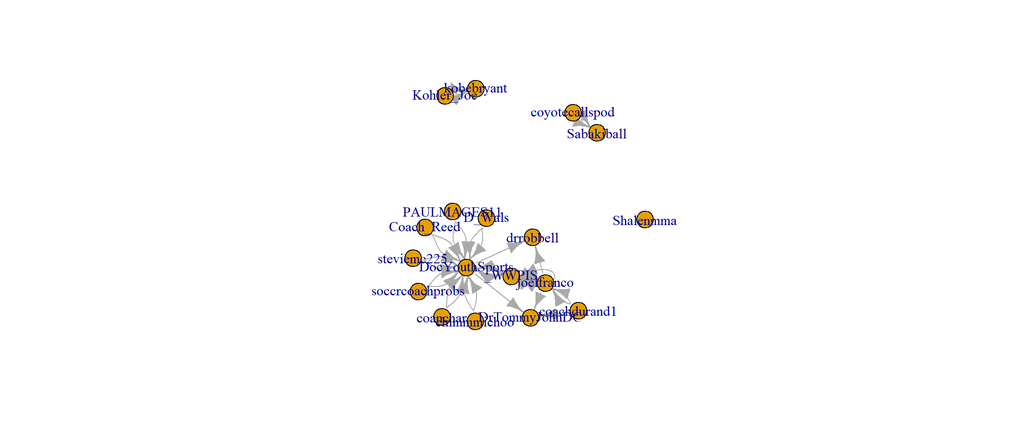

```r
## search for #rstats tweets
drk <- search_tweets("#dontretirekid", n = 200)

## create from-to data frame representing retweet/mention/reply connections
drk_net_data <- network_data(drk, "retweet,mention,reply")

drk_net <- network_graph(drk)
plot(drk_net)
```

```r
library(tidygraph)
library(ggraph)

drk_tidy <-
  drk_net_data %>%
  as_tbl_graph()

drk_tidy <- drk_tidy %>%
  activate(nodes) %>%
  mutate(
    username = lookup_users(name) %>% pull(screen_name),
    importance = centrality_betweenness()
    )

drk_tidy
```

```
## # A tbl_graph: 17 nodes and 36 edges
## #
## # A directed multigraph with 3 components
## #
## # Node Data: 17 x 3 (active)
##   name                username       importance
##   <chr>               <chr>               <dbl>
## 1 867651969753772032  _WWPIS                 10
## 2 1229826979282739200 PAULMAGES11             0
## 3 164412473           D_Wals                  0
## 4 4048869974          coachdurand1            0
## 5 1290044520          Kohler_Joe              0
## 6 1108448653830553601 coyotecallspod          0
## # ... with 11 more rows
## #
## # Edge Data: 36 x 3
##    from    to type
##   <int> <int> <chr>
## 1     1    12 retweet
## 2     1    13 retweet
## 3     1    13 retweet
## # ... with 33 more rows
```

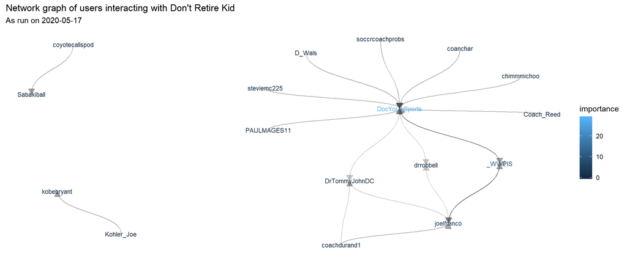

```r
  thm <- theme_minimal() +
  theme(
    # legend.position = "none",
     axis.title = element_blank(),
     axis.text = element_blank(),
     panel.grid = element_blank(),
     panel.grid.major = element_blank()
  )

theme_set(thm)

drk_tidy %>%
  ggraph(layout = "kk") +
    geom_node_text(aes(label = username, color=importance), size = 3) +
    geom_edge_diagonal(color = "gray30", alpha = 0.3, arrow = arrow(type = "closed", length = unit(.3, "cm"))) +
    labs(title = "Network graph of users interacting with Don't Retire Kid",
         subtitle = glue::glue("As run on {Sys.Date()}"))
```

Try to get the people who retweeted Aspen’s tweets

```r
data <-
  unq_users %>%
  map(function(x) get_timeline(x, n = 1000)) %>%    # read in all the files individually
  reduce(rbind)  %>%       # reduce with rbind into one dataframe
  mutate(Year = lubridate::year(as.Date(created_at))) %>%
  filter(Year == 2020,
         created_at >= FirstPrmt$MinDt) %>%
  # filter(str_detect(text, regex("#dontretirekid", ignore_case = TRUE)))
  ungroup() %>%
  select(status_id, reply_to_status_id, created_at, screen_name, reply_to_screen_name, mentions_screen_name,
         text, source, hashtags, urls_expanded_url, media_url,
         geo_coords, country, location,
         account_created_at, followers_count, friends_count)
```

## Gathering Participatation

## Sport Participation

# Analysis

It might be interesting to do a sentiment analysis on the responses to the Don’t Retire Kid tweets.

A work by [Phil Walker](https://github.com/phildwalker)

*philwalker2012@gmail.com*